# Guided tutorial

```r
library(COTAN)
library(data.table)
library(Matrix)
library(ggrepel)
library(factoextra)
```

```r
library(Rtsne)
library(utils)
library(plotly)
library(tidyverse)
library(htmlwidgets)
library(MASS)
library(dendextend)
mycolours <- c("A" = "#8491B4B2","B"="#E64B35FF")
my_theme = theme(axis.text.x = element_text(size = 14, angle = 0, hjust = .5, vjust = .5, face = "plain", colour ="#3C5488FF" ),
                 axis.text.y = element_text( size = 14, angle = 0, hjust = 0, vjust = .5, face = "plain", colour ="#3C5488FF"),
                 axis.title.x = element_text( size = 14, angle = 0, hjust = .5, vjust = 0, face = "plain", colour ="#3C5488FF"),
                 axis.title.y = element_text( size = 14, angle = 90, hjust = .5, vjust = .5, face = "plain", colour ="#3C5488FF"))
data_dir = tempdir()
```

```r
#load(system.file("data", "ERCCraw.rda", package = "COTAN", mustWork = TRUE))
data("ERCCraw", package = "COTAN")

ERCCraw = as.data.frame(ERCCraw)
rownames(ERCCraw) = ERCCraw$V1
ERCCraw = ERCCraw[,2:ncol(ERCCraw)]
ERCCraw[1:5,1:5]
```

```
#>            AAACCGTGAAGCCT.1 AAACGCACTGCTGA.1 AAACTTGACCGAAT.1 AAAGACGAGGAAGC.1
#> ERCC-00002             1662             4036             3919             4124
#> ERCC-00003               95              283              298              290
#> ERCC-00004               25               75               70               75
#> ERCC-00009               41               57               78               98
#> ERCC-00012                0                0                0                0
#>            AAAGACGATCCGAA.1
#> ERCC-00002             4220
#> ERCC-00003              312
#> ERCC-00004               87
#> ERCC-00009               87
#> ERCC-00012                0
```

Define a directory where the output will be stored.

```r
#out_dir = out_dir
out_dir = tempdir()
```

# Analytical pipeline

Inizialise the COTAN object with the row count table and the metadata for the experiment.

```r
obj = new("scCOTAN",raw = ERCCraw)
#obj = initRaw(obj,GEO="GSM2861514" ,sc.method="Drop_seq",cond = "mouse cortex E17.5")
obj = initRaw(obj,GEO="ERCC" ,sc.method="10X",cond = "negative ERCC dataset")
```

```
#> [1] "Initializing S4 object"
```

Now we can start the cleaning. Analysis requires and starts from a matrix of raw UMI counts after removing possible cell doublets or multiplets and low quality or dying cells (with too high mtRNA percentage, easily done with Seurat or other tools).

If we do not want to consider the mitochondrial genes we can remove them before starting the analysis.

```r
genes_to_rem = rownames(obj@raw[grep('^mt', rownames(obj@raw)),])
obj@raw = obj@raw[!rownames(obj@raw) %in% genes_to_rem,]
cells_to_rem = colnames(obj@raw[which(colSums(obj@raw) == 0)])
obj@raw = obj@raw[,!colnames(obj@raw) %in% cells_to_rem]
```

We want also to define a prefix to identify the sample.

```r
#t = "E17.5_cortex"
t = "ERCC"

print(paste("Condition ",t,sep = ""))
```

```
#> [1] "Condition ERCC"
```

```r
#--------------------------------------
n_cells = length(colnames(obj@raw))
print(paste("n cells", n_cells, sep = " "))
```

```
#> [1] "n cells 1015"
```

```r
n_it = 1
```

## Data cleaning

First we create the directory to store all information regarding the data cleaning.

```r
if(!file.exists(out_dir)){
  dir.create(file.path(out_dir))
}

if(!file.exists(paste(out_dir,"cleaning", sep = ""))){
  dir.create(file.path(out_dir, "cleaning"))
}
```

```r
ttm = clean(obj)
```

```
#> [1] "Start estimation mu with linear method"
#> [1]   88 1015
#>       rowname AACCTACTAGTGTC.1 AACGTTCTTGCCCT.1 AACTGTCTTGTCGA.1
#> 1  ERCC-00002       3868.72569       3666.17330       3583.62138
#> 50 ERCC-00096       2155.29007       2103.20280       2365.56635
#> 39 ERCC-00074       1193.60684       1170.86640       1098.13070
#> 65 ERCC-00130        738.75666        754.80039        639.59647
#> 59 ERCC-00113        565.81363        774.40559        834.76745
#> 88 ERCC-00171        452.85084        417.15519        493.80610
#> 25 ERCC-00046        397.86895        393.19327        399.74779
#> 2  ERCC-00003        256.91538        281.00794        249.25451
#> 73 ERCC-00145        156.94830        144.86068        101.11268
#> 23 ERCC-00043        126.95818        123.07712        122.27580
#> 57 ERCC-00111         74.97530         79.51000         61.13790
#> 4  ERCC-00009         55.98156         81.68835         84.65247
```

[output cut: 179 more lines]

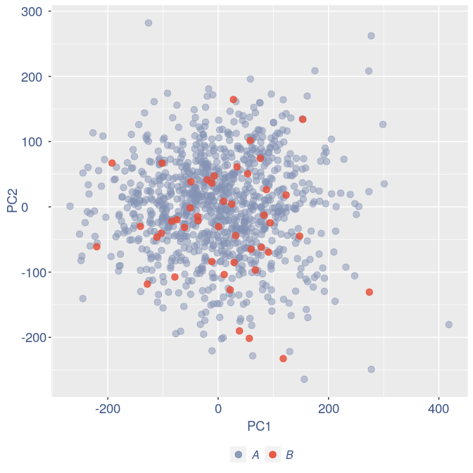

```r
obj = ttm$object

ttm$pca.cell.2
```

Run this when B cells need to be removed.

```r
pdf(file.path(out_dir,"cleaning",paste(t,"_",n_it,"_plots_before_cells_exlusion.pdf", sep = "")))
ttm$pca.cell.2
ggplot(ttm$D, aes(x=n,y=means)) + geom_point() +
  geom_text_repel(data=subset(ttm$D, n > (max(ttm$D$n)- 15) ), aes(n,means,label=rownames(ttm$D[ttm$D$n > (max(ttm$D$n)- 15),])),
                  nudge_y      = 0.05,
                  nudge_x      = 0.05,
                  direction    = "x",
                  angle        = 90,
                  vjust        = 0,
                  segment.size = 0.2)+
  ggtitle("B cell group genes mean expression")+my_theme +
  theme(plot.title = element_text(color = "#3C5488FF", size = 20, face = "italic",vjust = - 5,hjust = 0.02 ))
dev.off()

if (length(ttm$cl1) < length(ttm$cl2)) {
  to_rem = ttm$cl1
}else{
  to_rem = ttm$cl2
}
n_it = n_it+1
obj@raw = obj@raw[,!colnames(obj@raw) %in% to_rem]
#obj@raw = obj@raw[rownames(obj@raw) %in% rownames(cells),colnames(obj@raw) %in% colnames(cells)]
gc()

ttm = clean(obj)
#ttm = clean.sqrt(obj, cells)
obj = ttm$object

ttm$pca.cell.2
```

Run this only in the last iteration, instead the previous code, when B cells group has not to be removed

```r
pdf(file.path(out_dir,"cleaning",paste(t,"_",n_it,"_plots_before_cells_exlusion.pdf", sep = "")))
ttm$pca.cell.2
ggplot(ttm$D, aes(x=n,y=means)) + geom_point() +
  geom_text_repel(data=subset(ttm$D, n > (max(ttm$D$n)- 15) ), aes(n,means,label=rownames(ttm$D[ttm$D$n > (max(ttm$D$n)- 15),])),
                  nudge_y      = 0.05,
                  nudge_x      = 0.05,
                  direction    = "x",
                  angle        = 90,
                  vjust        = 0,
                  segment.size = 0.2)+
  ggtitle(label = "B cell group genes mean expression", subtitle = " - B group NOT removed -")+my_theme +
  theme(plot.title = element_text(color = "#3C5488FF", size = 20, face = "italic",vjust = - 10,hjust = 0.02 ),
        plot.subtitle = element_text(color = "darkred",vjust = - 15,hjust = 0.01 ))

dev.off()
```

To color the pca based on nu_j (so the cells’ efficiency)

```r
nu_est = round(obj@nu, digits = 7)

plot.nu <-ggplot(ttm$pca_cells,aes(x=PC1,y=PC2, colour = log(nu_est)))

plot.nu = plot.nu + geom_point(size = 1,alpha= 0.8)+
  scale_color_gradient2(low = "#E64B35B2",mid =  "#4DBBD5B2", high =  "#3C5488B2" ,
                        midpoint = log(mean(nu_est)),name = "ln(nu)")+
  ggtitle("Cells PCA coloured by cells efficiency") +
  my_theme +  theme(plot.title = element_text(color = "#3C5488FF", size = 20),
                    legend.title=element_text(color = "#3C5488FF", size = 14,face = "italic"),
                    legend.text = element_text(color = "#3C5488FF", size = 11),
                    legend.key.width = unit(2, "mm"),
                    legend.position="right")

pdf(file.path(out_dir,"cleaning",paste(t,"_plots_PCA_efficiency_colored.pdf", sep = "")))
plot.nu
dev.off()
```

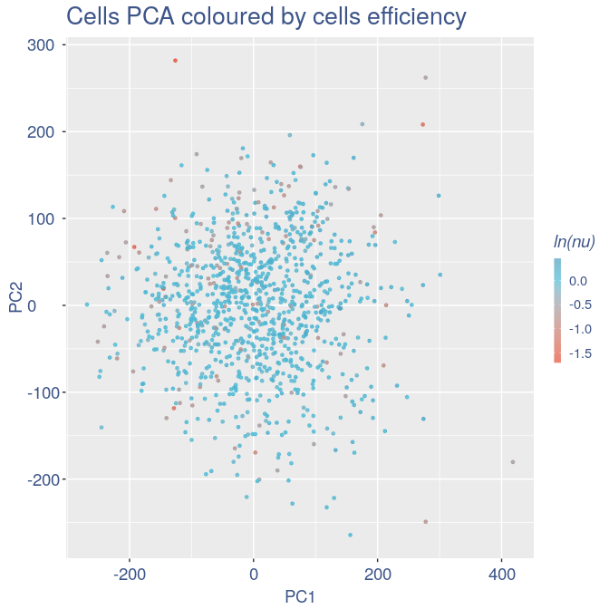

```r
plot.nu
```

The next part is use to remove the cells with efficiency too low.

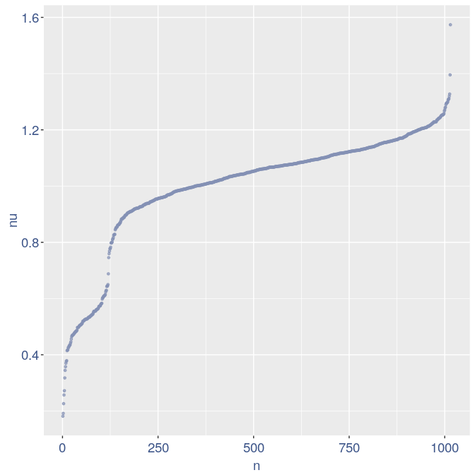

```r
nu_df = data.frame("nu"= sort(obj@nu), "n"=c(1:length(obj@nu)))

ggplot(nu_df, aes(x = n, y=nu)) +
    geom_point(colour = "#8491B4B2", size=1)+
    my_theme #+ ylim(0,1) + xlim(0,70)
```

We can zoom on the smallest values and, if we detect a clear elbow, we can decide to remove the cells.

```r
yset = 0.4#threshold to remove low UDE cells
plot.ude <- ggplot(nu_df, aes(x = n, y=nu)) +
    geom_point(colour = "#8491B4B2", size=1) +
    my_theme + ylim(0,1) + xlim(0,400) +
    geom_hline(yintercept=yset, linetype="dashed", color = "darkred") +
    annotate(geom="text", x=200, y=0.25,
             label=paste("to remove cells with nu < ",yset,sep = " "),
             color="darkred", size=4.5)


pdf(file.path(out_dir,"cleaning",paste(t,"_plots_efficiency.pdf", sep = "")))
plot.ude
dev.off()
```

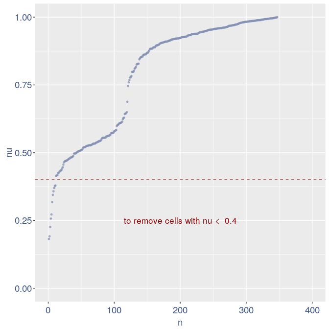

```r
plot.ude
```

We also save the defined threshold in the metadata and re run the estimation

```r
obj@meta[(nrow(obj@meta)+1),1:2] = c("Threshold low UDE cells:",yset)

to_rem = rownames(nu_df[which(nu_df$nu < yset),])
obj@raw = obj@raw[, !colnames(obj@raw) %in% to_rem]
```

Repeat the estimation after the cells are removed

```r
ttm = clean(obj)
```

```
#> [1] "Start estimation mu with linear method"
#> [1]   88 1004
#>       rowname ATACTCTGCCAAGT.1
#> 1  ERCC-00002       3891.24110
#> 50 ERCC-00096       2051.86238
#> 39 ERCC-00074       1068.85718
#> 65 ERCC-00130        618.13427
#> 59 ERCC-00113        613.84167
#> 25 ERCC-00046        476.47850
#> 88 ERCC-00171        476.47850
#> 2  ERCC-00003        270.43374
#> 73 ERCC-00145        238.23925
#> 23 ERCC-00043        156.67987
#> 4  ERCC-00009        113.75388
#> 3  ERCC-00004         83.70568
#> 11 ERCC-00022         70.82789
#> 57 ERCC-00111         64.38899
#> 22 ERCC-00042         62.24269
```

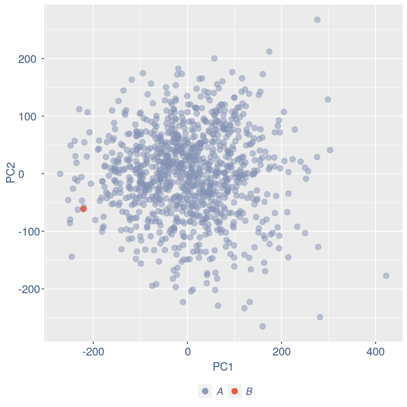

```r
obj = ttm$object
ttm$pca.cell.2
```

In case we do not want to remove anything, we can run:

```r
pdf(file.path(out_dir,"cleaning",paste(t,"_plots_efficiency.pdf", sep = "")))
ggplot(nu_df, aes(x = n, y=nu)) + geom_point(colour = "#8491B4B2", size=1) +my_theme + #xlim(0,100)+
  annotate(geom="text", x=50, y=0.25, label="nothing to remove ", color="darkred")
dev.off()
```

Just to check again, we plot the final efficiency colored PCA

```r
nu_est = round(obj@nu, digits = 7)
plot.nu <-ggplot(ttm$pca_cells,aes(x=PC1,y=PC2, colour = log(nu_est)))
plot.nu = plot.nu + geom_point(size = 2,alpha= 0.8)+
  scale_color_gradient2(low = "#E64B35B2",mid =  "#4DBBD5B2", high =  "#3C5488B2" ,
                        midpoint = log(mean(nu_est)),name = "ln(nu)")+
  ggtitle("Cells PCA coloured by cells efficiency: last") +
  my_theme +  theme(plot.title = element_text(color = "#3C5488FF", size = 20),
                    legend.title=element_text(color = "#3C5488FF", size = 14,face = "italic"),
                    legend.text = element_text(color = "#3C5488FF", size = 11),
                    legend.key.width = unit(2, "mm"),
                    legend.position="right")

pdf(file.path(out_dir,"cleaning",paste(t,"_plots_PCA_efficiency_colored_FINAL.pdf", sep = "")))
plot.nu
dev.off()
```

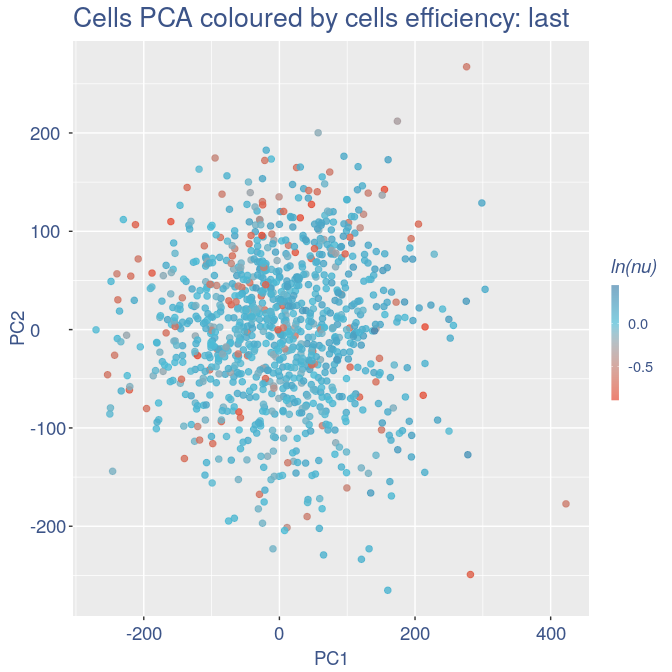

```r
plot.nu
```

## COTAN analysis

In this part all the contingency tables are computed and used to get the statistics (S) To storage efficiency of all the observed tables only the yes_yes is stored. Note that if will be necessary re-computing the yes-yes table, the yes-yes table should be cancelled before running cotan_analysis.

```r
# obj@yes_yes = c()
obj = cotan_analysis(obj,cores = 2)
```

```
#> [1] "cotan analysis"
#> [1] "mu estimator creation"
#> [1] "save effective constitutive genes"
#> [1] "start a minimization"
#> [1] "Final trance!"
#> [1] "a min: -0.147216796875 | a max 13.5546875 | negative a %: 26.984126984127"
```

COEX evaluation and storing

```r
obj = get.coex(obj)
```

```
#> [1] "coex dataframe creation"
#> [1] "Generating contingency tables for observed data"
#> [1] "creation of observed yes/yes contingency table"
#> [1] "mu estimator creation"
#> [1] "expected contingency tables creation"
#> [1] "The distance between estimated n of zeros and observed number of zero is 0.0041370202609155 over 63"
#> [1] "Done"
#> [1] "coex estimation"
#> [1] "Diagonal coex values substituted with 0"
```

```r
# saving the structure
saveRDS(obj,file = paste(out_dir,t,".cotan.RDS", sep = ""))
```

# Analysis of the elaborated data

## GDI

The next function can directly plot the GDI for the dataset with the 1.5 threshold (in red) and the two higher quantiles (in blue).

```
#> [1] "GDI plot "
#> [1] "function to generate GDI dataframe"
#> [1] "Using S"
#> [1] "function to generate S "
```

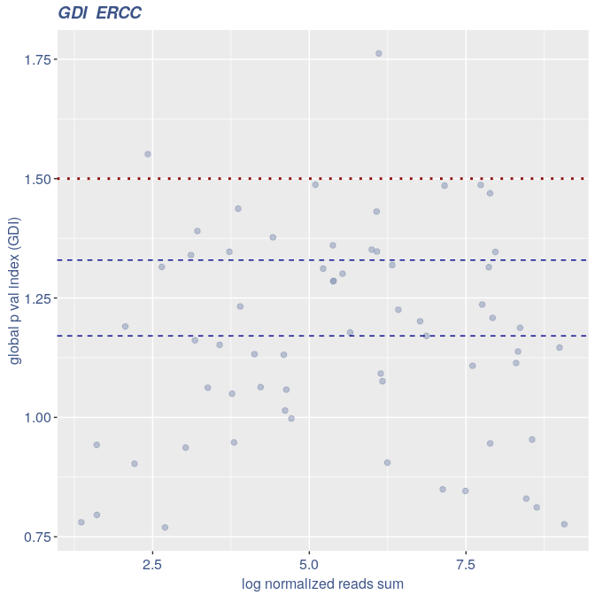

```r
plot_GDI(obj, cond = "ERCC")
```

If a more complex plot is needed, or if we want to analyze more in detail the GDI data, we can get directly the GDI dataframe.

```r
quant.p = get.GDI(obj)
```

```
#> [1] "function to generate GDI dataframe"
#> [1] "Using S"
#> [1] "function to generate S "
```

```r
head(quant.p)
```

```
#>            sum.raw.norm       GDI exp.cells
#> ERCC-00012     3.175703 1.1614016  2.390438
#> ERCC-00013     5.995188 1.3512611 27.788845
#> ERCC-00014     6.077256 1.3472800 34.860558
#> ERCC-00016     3.569692 1.1519108  3.685259
#> ERCC-00017     1.609829 0.7957173  0.498008
#> ERCC-00019     7.157739 1.4853627 66.135458
```

In the third column of this dataframe is reported the percentage of cells expressing the gene.

Next we can define some gene sets (in this case three) that we want to specifically label in the GDI plot.

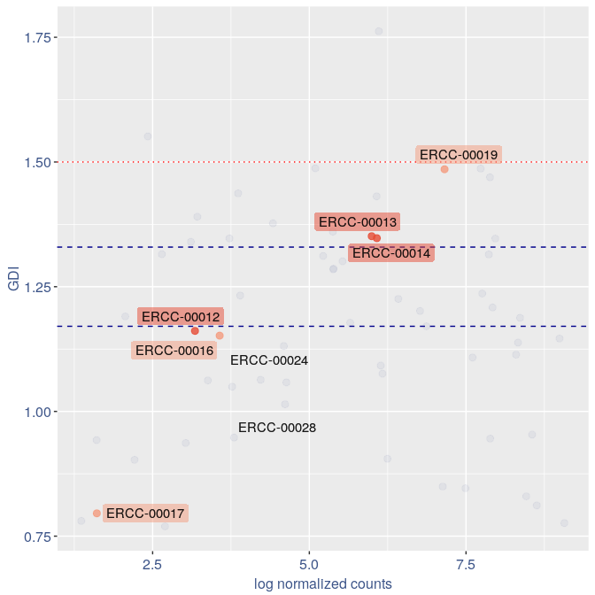

```r
AA=c("ERCC-00012","ERCC-00013","ERCC-00014")
BB=c("ERCC-00016","ERCC-00017","ERCC-00019")
CC=c("ERCC-00022","ERCC-00024","ERCC-00028")

text.size = 12

quant.p$highlight = with(quant.p, ifelse(rownames(quant.p) %in% AA, "AA",
                                                 ifelse(rownames(quant.p) %in% CC,"Constitutive" ,
                                                               ifelse(rownames(quant.p) %in% BB,"BB" , "normal"))))

textdf <- quant.p[rownames(quant.p) %in% c(AA,CC,BB), ]
mycolours <- c("Con" = "#00A087FF","AA"="#E64B35FF","BB"="#F39B7FFF","normal" = "#8491B4B2")
f1 = ggplot(subset(quant.p,highlight == "normal" ), aes(x=sum.raw.norm, y=GDI)) +  geom_point(alpha = 0.1, color = "#8491B4B2", size=2.5)
GDI_plot = f1 +  geom_point(data = subset(quant.p,highlight != "normal"  ), aes(x=sum.raw.norm, y=GDI, colour=highlight),size=2.5,alpha = 0.8) +
  geom_hline(yintercept=quantile(quant.p$GDI)[4], linetype="dashed", color = "darkblue") +
  geom_hline(yintercept=quantile(quant.p$GDI)[3], linetype="dashed", color = "darkblue") +
  geom_hline(yintercept=1.5, linetype="dotted", color = "red", size= 0.5) +
  scale_color_manual("Status", values = mycolours)  +
  scale_fill_manual("Status", values = mycolours)  +
  xlab("log normalized counts")+ylab("GDI")+
  geom_label_repel(data =textdf , aes(x=sum.raw.norm, y=GDI, label = rownames(textdf),fill=highlight),
                   label.size = NA,
                   alpha = 0.5,
                   direction ="both",
                   na.rm=TRUE,
                   seed = 1234) +
  geom_label_repel(data =textdf , aes(x=sum.raw.norm, y=GDI, label = rownames(textdf)),
                   label.size = NA,
                   segment.color = 'black',
                   segment.size = 0.5,
                   direction = "both",
                   alpha = 0.8,
                   na.rm=TRUE,
                   fill = NA,
                   seed = 1234) +
  theme(axis.text.x = element_text(size = text.size, angle = 0, hjust = .5, vjust = .5, face = "plain", colour ="#3C5488FF" ),
        axis.text.y = element_text( size = text.size, angle = 0, hjust = 0, vjust = .5, face = "plain", colour ="#3C5488FF"),
        axis.title.x = element_text( size = text.size, angle = 0, hjust = .5, vjust = 0, face = "plain", colour ="#3C5488FF"),
        axis.title.y = element_text( size = text.size, angle = 90, hjust = .5, vjust = .5, face = "plain", colour ="#3C5488FF"),
        legend.title = element_blank(),
        legend.text = element_text(color = "#3C5488FF",face ="italic" ),
        legend.position = "bottom")  # titl)
legend <- cowplot::get_legend(GDI_plot)
GDI_plot =GDI_plot + theme(
        legend.position = "none")
GDI_plot
```

## Heatmaps

```
#> [1] "plot heatmap"
#> [1] "Loading condition ERCC"
#> [1] "ERCC-00016" "ERCC-00017" "ERCC-00019"
#> [1] "Get p-values on a set of genes on columns on a set of genes on rows"
#> [1] "Using function S"
#> [1] "function to generate S "
#> [1] "Ref.col"
#> [1] "AA"
#> [1] "Const."
#> [1] "min coex: 0 max coex 0.0944668792763664"
```

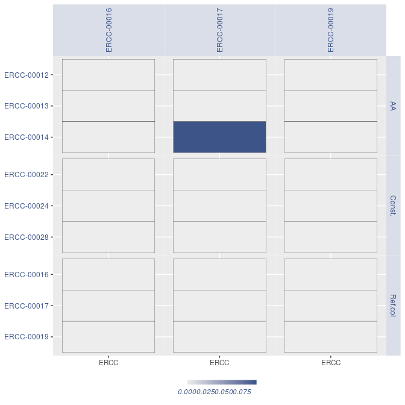

```r
list.genes = list("Ref.col"= BB, "AA"=AA, "Const."=CC )

plot_heatmap(df_genes = list.genes,sets = c(1:3),conditions = "ERCC",dir = out_dir)
```

We can also plot a general heatmap of coex values based on some markers like the following one.

```
#> [1] "ploting a general heatmap"
#> [1] "ERCC-00014" "ERCC-00019"
#> [1] "Get p-values on a set of genes on columns genome wide on rows"
#> [1] "Using function S"
#> [1] "function to generate S "
```

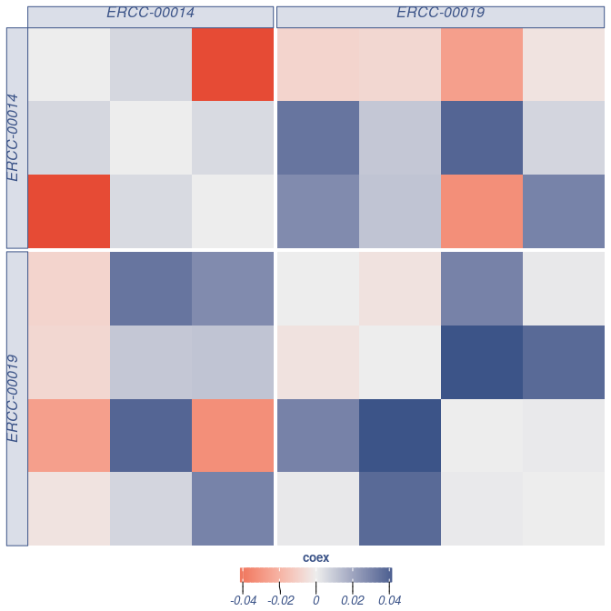

```r
plot_general.heatmap(prim.markers = c("ERCC-00014","ERCC-00019"), condition = "ERCC",dir = out_dir, p_value = 0.05,)
```

## Get data tables

Sometimes we can also be interested in the numbers present directly in the contingency tables for two specific genes. To get them we can use two functions:

1. get.observed.ct to produce the observed data

```r
get.observed.ct(object = obj, g1 = "ERCC-00014",g2 = "ERCC-00019")
```

```
#>                ERCC-00014.yes ERCC-00014.no
#> ERCC-00019.yes            241           423
#> ERCC-00019.no             109           231
```

2. get.expected.ct to produce the expected values

```r
get.expected.ct(object = obj, g1 = "ERCC-00014",g2 = "ERCC-00019")
```

```
#>                ERCC-00014.yes ERCC-00014.no
#> ERCC-00019.yes       235.7119      428.2888
#> ERCC-00019.no        114.2885      225.7108
```

The next few lines are just to clean after compilation of the documentation.

```r
if (file.exists(paste(out_dir,t,".cotan.RDS", sep = ""))) {
  #Delete file if it exists
  file.remove(paste(out_dir,t,".cotan.RDS", sep = ""))
}
```

```
#> [1] TRUE
```

```r
unlink(paste(out_dir,"cleaning", sep = ""),recursive = TRUE)
```